# Terroir

Erin Treiber

#setup ##clears everything out

```r
rm(list = ls())
gc()
```

```
##          used (Mb) gc trigger (Mb) max used (Mb)
## Ncells 446682 23.9     954410   51   643648 34.4
## Vcells 801299  6.2    8388608   64  1648626 12.6
```

##set working directory

```r
#setwd("~/Desktop/Terroir_2019")
setwd("C:/Users/clark776/Dropbox/ENOLOGY DATA/Terroir Study Matt Working Data")
```

##load packages

```r
library(ggplot2)
library(plyr)
library(dplyr)
library(tidyr)
library(tibble)
library(reshape2)
```

#Cluster data 2019 #Brianna ##load data

```r
data <- read.csv("Terroir_2019_Brianna.csv")
```

##partition data

```r
weekb <- filter(data, data$sample_week =="b")
weekc <- filter(data, data$sample_week =="c")
```

#aspect ratio ##Linear model and ANOVA

```r
asp_rat <- lm(aspect_ratio ~ location+cluster+image+date+location*cluster*image*date, data)
anova(asp_rat)
```

```
## Analysis of Variance Table
##
## Response: aspect_ratio
##                             Df Sum Sq Mean Sq F value   Pr(>F)
## location                     2 0.2905 0.14524  2.8943 0.061083 .
## cluster                      1 0.0022 0.00218  0.0434 0.835587
## image                        1 0.0002 0.00024  0.0049 0.944491
## date                         1 0.0161 0.01611  0.3211 0.572512
## location:cluster             2 0.0694 0.03470  0.6915 0.503757
## location:image               2 0.0158 0.00790  0.1574 0.854657
## cluster:image                1 0.0298 0.02985  0.5948 0.442821
## location:date                1 0.5171 0.51713 10.3054 0.001902 **
## cluster:date                 1 0.0531 0.05309  1.0579 0.306761
## image:date                   1 0.0009 0.00086  0.0171 0.896280
## location:cluster:image       2 0.0382 0.01911  0.3809 0.684460
## location:cluster:date        1 0.4781 0.47810  9.5274 0.002771 **
## location:image:date          1 0.0037 0.00373  0.0744 0.785773
## cluster:image:date           1 0.0513 0.05128  1.0219 0.315074
## location:cluster:image:date  1 0.0164 0.01641  0.3270 0.569030
## Residuals                   81 4.0647 0.05018
## ---
## Signif. codes:  0 '***' 0.001 '**' 0.01 '*' 0.05 '.' 0.1 ' ' 1
```

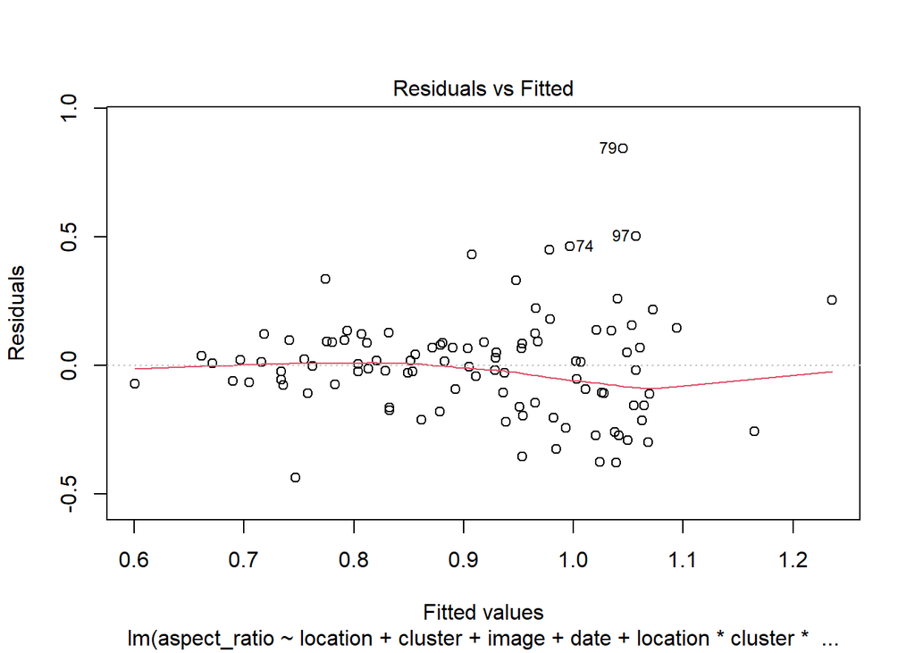

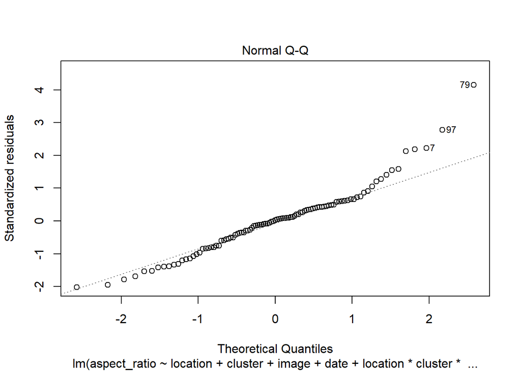

```r
plot(asp_rat,which=c(1,2))
```

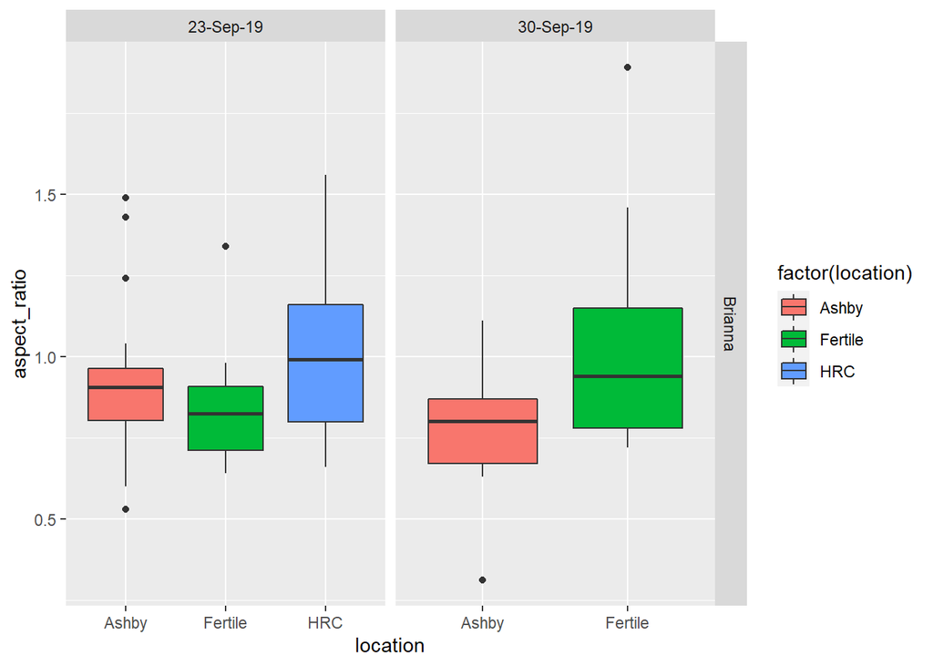

```r
ggplot(data, aes(aspect_ratio, location, fill=factor(location)))+ #use this box plot!
  geom_boxplot()+
  coord_flip()+
  facet_grid(variety~date, scales="free")
```

##Linear model and ANOVA Week b only

```r
asp_rat_b <- lm(aspect_ratio ~ location+cluster+image+location*cluster*image, weekb)
anova(asp_rat_b)
```

```
## Analysis of Variance Table
##
## Response: aspect_ratio
##                        Df  Sum Sq  Mean Sq F value   Pr(>F)
## location                2 0.21920 0.109602  2.6138 0.083658 .
## cluster                 1 0.02948 0.029480  0.7030 0.405922
## image                   1 0.00033 0.000327  0.0078 0.930035
## location:cluster        2 0.46426 0.232130  5.5359 0.006866 **
## location:image          2 0.00322 0.001612  0.0384 0.962324
## cluster:image           1 0.09314 0.093140  2.2212 0.142669
## location:cluster:image  2 0.03653 0.018264  0.4356 0.649432
## Residuals              48 2.01273 0.041932
## ---
## Signif. codes:  0 '***' 0.001 '**' 0.01 '*' 0.05 '.' 0.1 ' ' 1
```

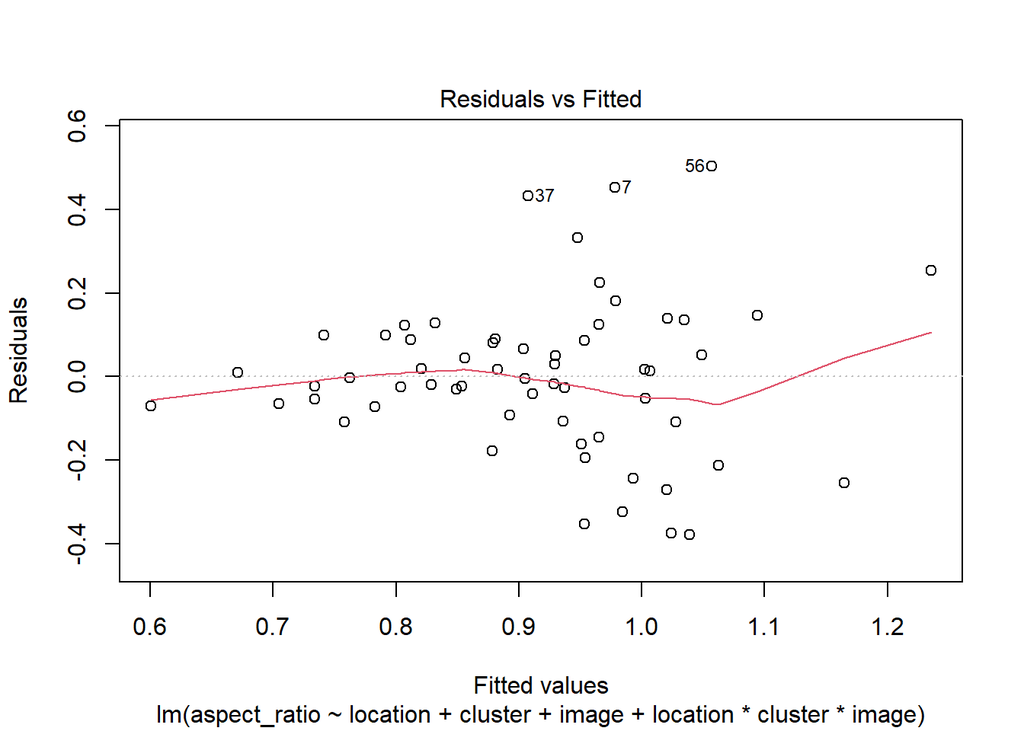

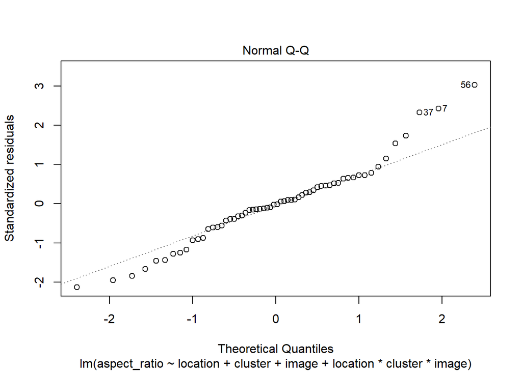

```r
plot(asp_rat_b,which=c(1,2))
```

##Linear model and ANOVA Week c only

```r
asp_rat_c <- lm(aspect_ratio ~ location+cluster+image+cluster*image*location, weekc)
anova(asp_rat_c)
```

```
## Analysis of Variance Table
##
## Response: aspect_ratio
##                        Df  Sum Sq Mean Sq F value   Pr(>F)
## location                1 0.60406 0.60406  9.7148 0.003773 **
## cluster                 1 0.01815 0.01815  0.2919 0.592620
## image                   1 0.00251 0.00251  0.0403 0.842096
## cluster:image           1 0.01003 0.01003  0.1613 0.690532
## location:cluster        1 0.09139 0.09139  1.4698 0.233988
## location:image          1 0.00830 0.00830  0.1335 0.717151
## location:cluster:image  1 0.00005 0.00005  0.0008 0.978215
## Residuals              33 2.05193 0.06218
## ---
## Signif. codes:  0 '***' 0.001 '**' 0.01 '*' 0.05 '.' 0.1 ' ' 1
```

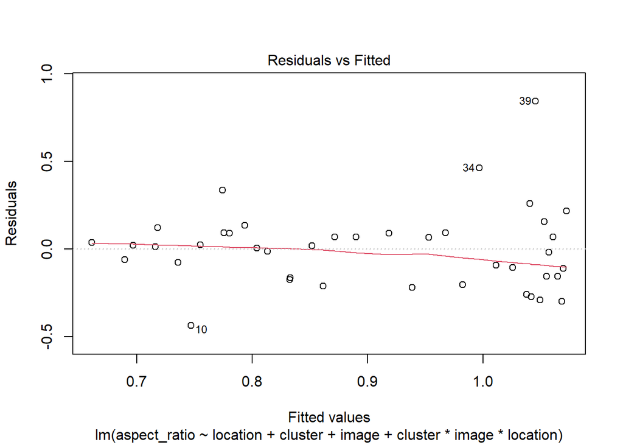

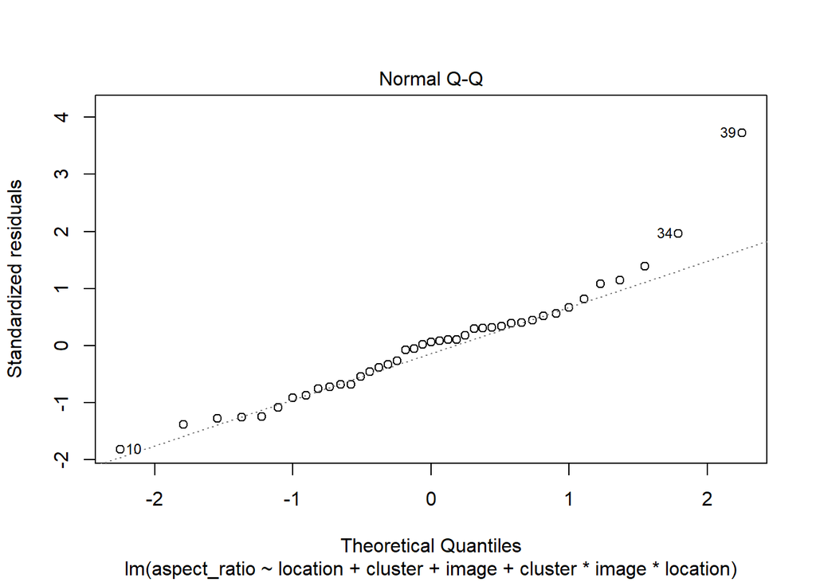

```r
plot(asp_rat_c,which=c(1,2))
```

#cluster roundness ##Linear model and ANOVA

```r
cl_rnd <- lm(cluster_roundness ~ location+cluster+image+date+location*cluster*image*date, data)
anova(cl_rnd)
```

```
## Analysis of Variance Table
##
## Response: cluster_roundness
##                             Df  Sum Sq   Mean Sq F value  Pr(>F)
## location                     2 0.02395 0.0119733  1.7660 0.17753
## cluster                      1 0.01914 0.0191407  2.8232 0.09677 .
## image                        1 0.00011 0.0001062  0.0157 0.90071
## date                         1 0.02612 0.0261154  3.8519 0.05312 .
## location:cluster             2 0.03291 0.0164535  2.4268 0.09471 .
## location:image               2 0.00245 0.0012255  0.1808 0.83497
## cluster:image                1 0.00096 0.0009575  0.1412 0.70805
## location:date                1 0.00506 0.0050631  0.7468 0.39005
## cluster:date                 1 0.00586 0.0058650  0.8651 0.35509
## image:date                   1 0.00078 0.0007814  0.1152 0.73513
## location:cluster:image       2 0.00002 0.0000123  0.0018 0.99819
## location:cluster:date        1 0.01792 0.0179157  2.6425 0.10793
## location:image:date          1 0.00225 0.0022478  0.3315 0.56635
## cluster:image:date           1 0.00096 0.0009642  0.1422 0.70707
## location:cluster:image:date  1 0.00152 0.0015225  0.2246 0.63686
## Residuals                   81 0.54917 0.0067799
## ---
## Signif. codes:  0 '***' 0.001 '**' 0.01 '*' 0.05 '.' 0.1 ' ' 1
```

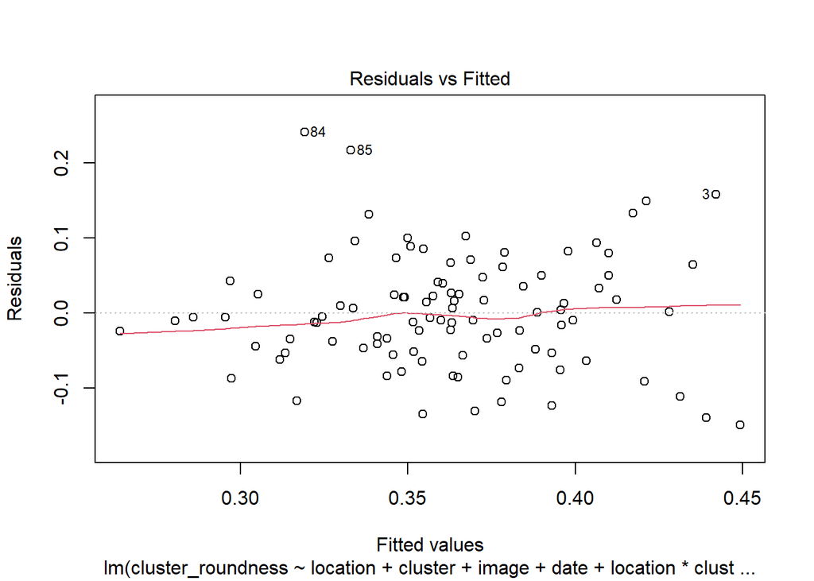

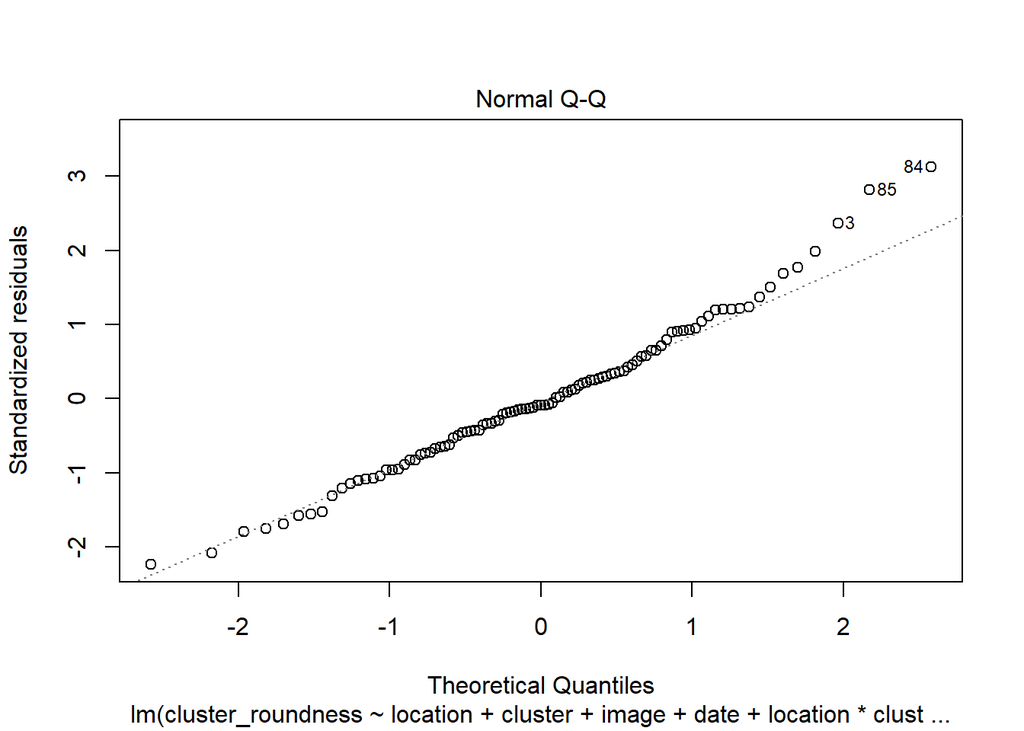

```r
plot(cl_rnd,which=c(1,2))
```

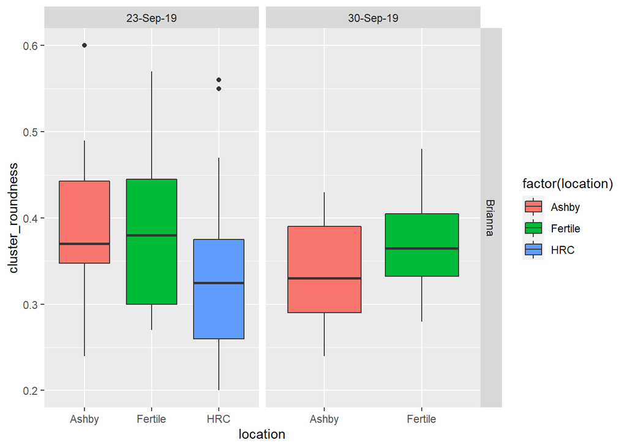

```r
ggplot(data, aes(cluster_roundness, location, fill=factor(location)))+ #use this box plot!
  geom_boxplot()+
  coord_flip()+
  facet_grid(variety~date, scales="free")
```

##Linear model and ANOVA week b only

```r
cl_rnd_b <- lm(cluster_roundness ~ location+cluster+image+location*cluster*image, weekb)
anova(cl_rnd_b)
```

```
## Analysis of Variance Table
##
## Response: cluster_roundness
##                        Df  Sum Sq   Mean Sq F value Pr(>F)
## location                2 0.03606 0.0180317  1.8946 0.1614
## cluster                 1 0.01208 0.0120768  1.2690 0.2656
## image                   1 0.00008 0.0000817  0.0086 0.9266
## location:cluster        2 0.03265 0.0163268  1.7155 0.1907
## location:image          2 0.00158 0.0007917  0.0832 0.9203
## cluster:image           1 0.00001 0.0000146  0.0015 0.9689
## location:cluster:image  2 0.00120 0.0006004  0.0631 0.9389
## Residuals              48 0.45682 0.0095172
```

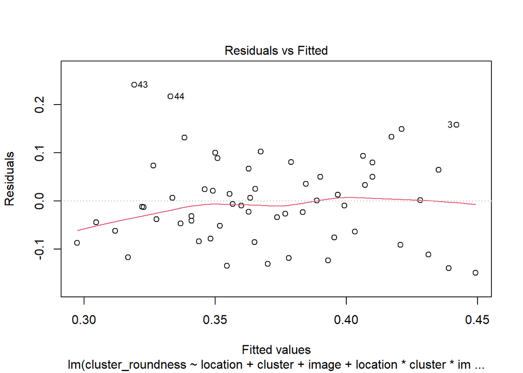

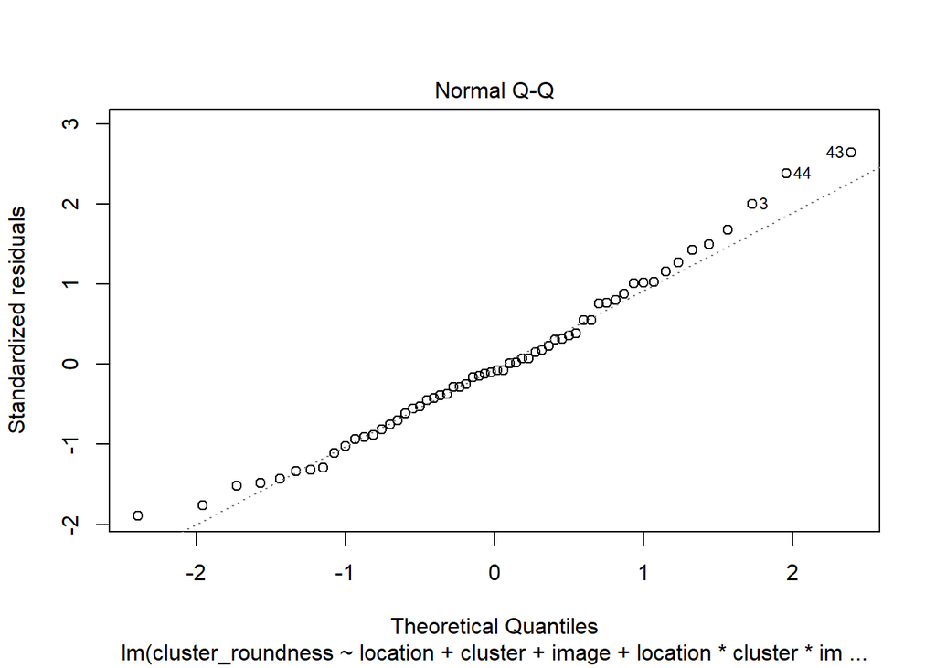

```r
plot(cl_rnd_b,which=c(1,2))
```

##Linear model and ANOVA week c only

```r
cl_rnd_c <- lm(cluster_roundness ~ location+cluster+image+location*cluster*image, weekc)
anova(cl_rnd_c)
```

```
## Analysis of Variance Table
##
## Response: cluster_roundness
##                        Df   Sum Sq   Mean Sq F value   Pr(>F)
## location                1 0.009739 0.0097388  3.4802 0.071018 .
## cluster                 1 0.007197 0.0071970  2.5719 0.118307
## image                   1 0.001579 0.0015791  0.5643 0.457855
## location:cluster        1 0.024004 0.0240039  8.5779 0.006127 **
## location:image          1 0.003393 0.0033933  1.2126 0.278781
## cluster:image           1 0.001609 0.0016090  0.5750 0.453663
## location:cluster:image  1 0.000514 0.0005141  0.1837 0.670977
## Residuals              33 0.092345 0.0027983
## ---
## Signif. codes:  0 '***' 0.001 '**' 0.01 '*' 0.05 '.' 0.1 ' ' 1
```

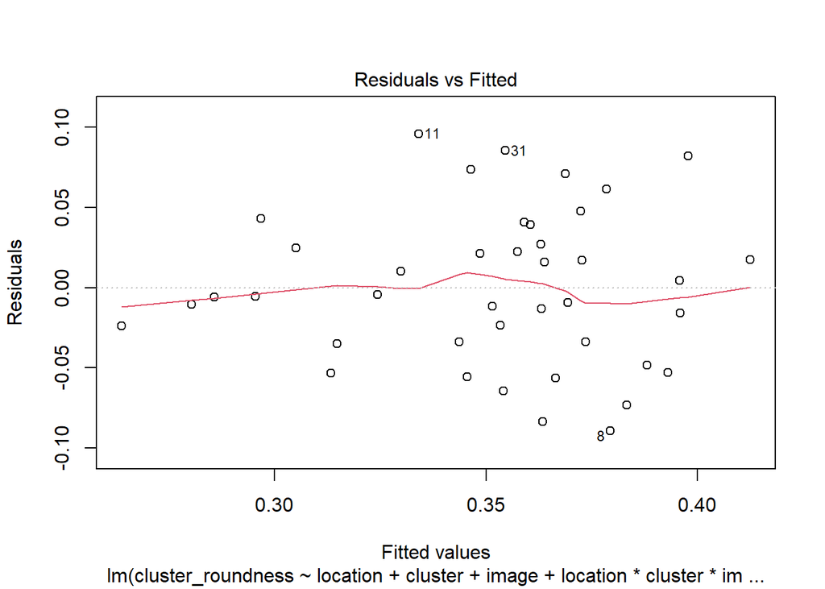

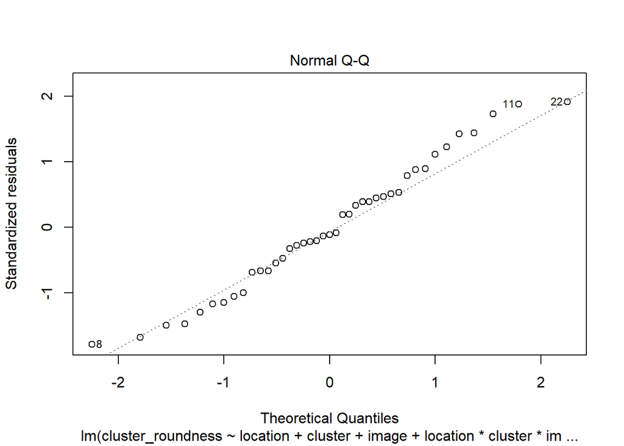

```r
plot(cl_rnd_c,which=c(1,2))
```

#compact shape factor ##Linear model and ANOVA

```r
cmp_shp <- lm(comp_shp_fact ~ location+cluster+image+date+location*cluster*image*date, data)
anova(cmp_shp)
```

```
## Analysis of Variance Table
##
## Response: comp_shp_fact
##                             Df Sum Sq Mean Sq F value   Pr(>F)
## location                     2  474.8  237.39  3.7321 0.028155 *
## cluster                      1   77.1   77.08  1.2118 0.274244
## image                        1    1.4    1.45  0.0227 0.880498
## date                         1  140.2  140.17  2.2037 0.141561
## location:cluster             2  675.0  337.51  5.3061 0.006832 **
## location:image               2   33.3   16.63  0.2614 0.770588
## cluster:image                1   20.3   20.31  0.3193 0.573593
## location:date                1   79.4   79.38  1.2479 0.267259
## cluster:date                 1    3.9    3.91  0.0614 0.804888
## image:date                   1    5.8    5.83  0.0917 0.762854
## location:cluster:image       2    2.9    1.43  0.0225 0.977790
## location:cluster:date        1  219.1  219.10  3.4445 0.067100 .
## location:image:date          1    5.0    4.97  0.0782 0.780480
## cluster:image:date           1    6.6    6.57  0.1033 0.748684
## location:cluster:image:date  1   10.1   10.06  0.1582 0.691842
## Residuals                   81 5152.2   63.61
## ---
## Signif. codes:  0 '***' 0.001 '**' 0.01 '*' 0.05 '.' 0.1 ' ' 1
```

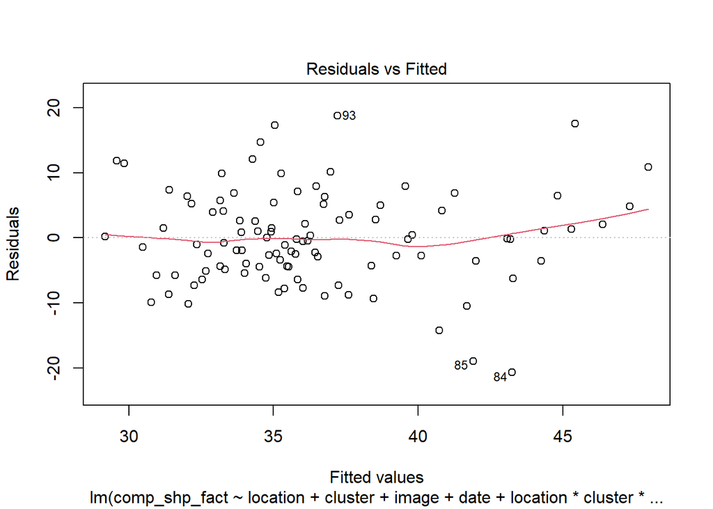

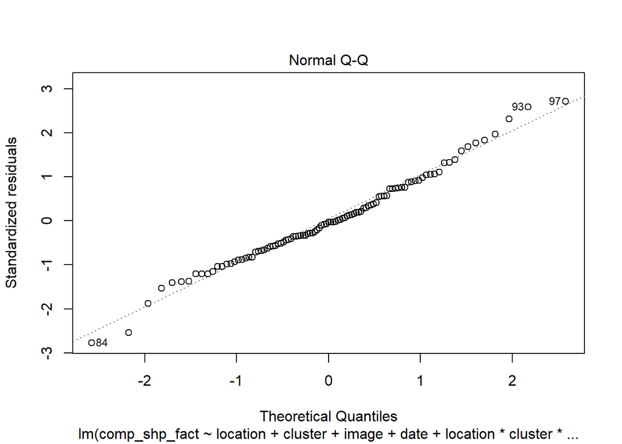

```r
plot(cmp_shp,which=c(1,2))
```

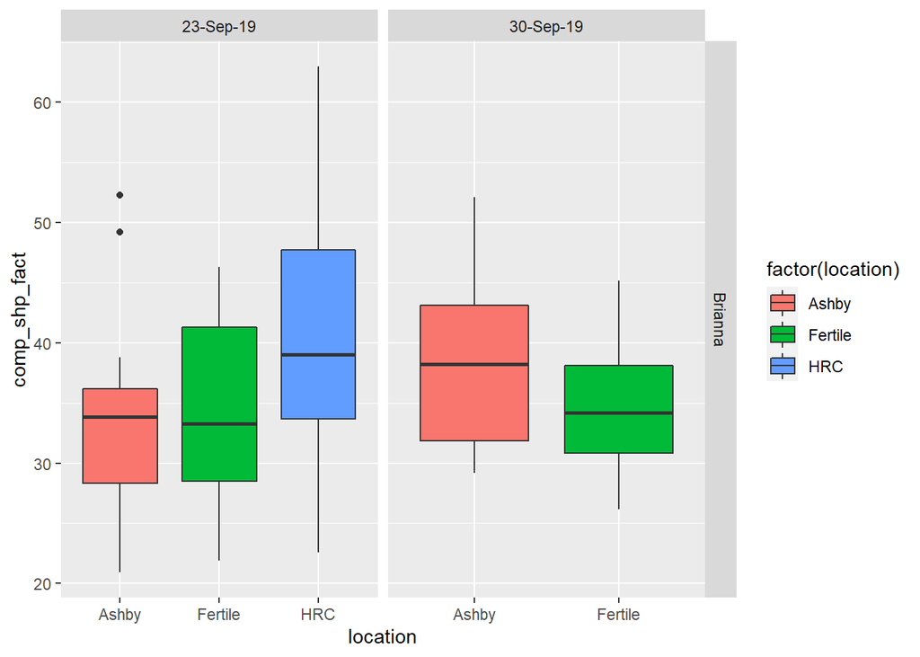

```r
ggplot(data, aes(comp_shp_fact, location, fill=factor(location)))+ #use this box plot!
  geom_boxplot()+
  coord_flip()+
  facet_grid(variety~date, scales="free")
```

##Linear model and ANOVA weeb b only

```r
cmp_shp_b <- lm(comp_shp_fact ~ location+cluster+image+location*cluster*image, weekb)
anova(cmp_shp_b)
```

```
## Analysis of Variance Table
##
## Response: comp_shp_fact
##                        Df Sum Sq Mean Sq F value  Pr(>F)
## location                2  557.2 278.623  3.1964 0.04975 *
## cluster                 1    2.9   2.885  0.0331 0.85641
## image                   1    1.8   1.831  0.0210 0.88539
## location:cluster        2  531.5 265.771  3.0490 0.05668 .
## location:image          2   10.1   5.054  0.0580 0.94374
## cluster:image           1    4.2   4.179  0.0479 0.82762
## location:cluster:image  2    4.2   2.090  0.0240 0.97632
## Residuals              48 4184.0  87.167
## ---
## Signif. codes:  0 '***' 0.001 '**' 0.01 '*' 0.05 '.' 0.1 ' ' 1
```

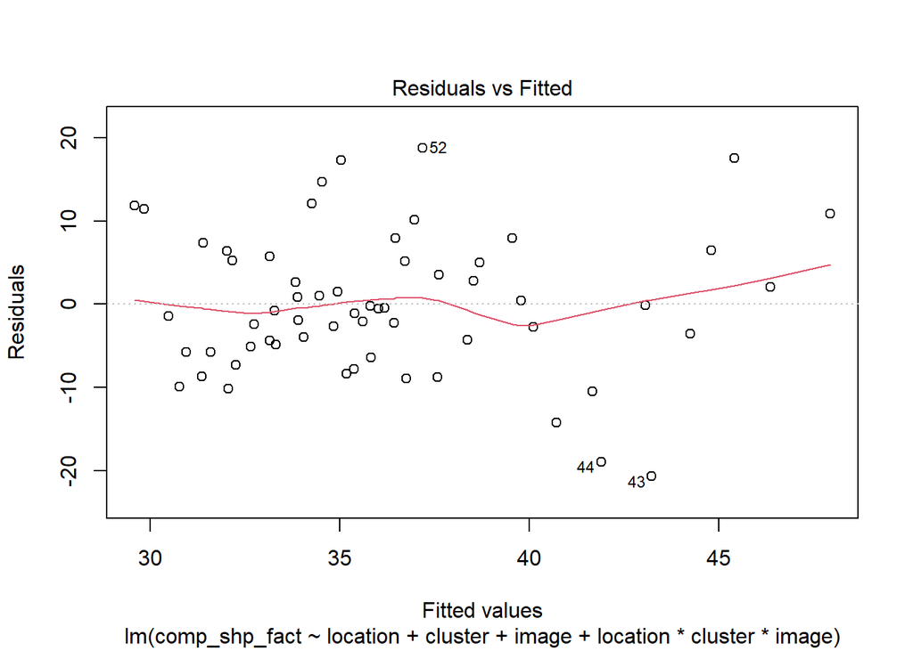

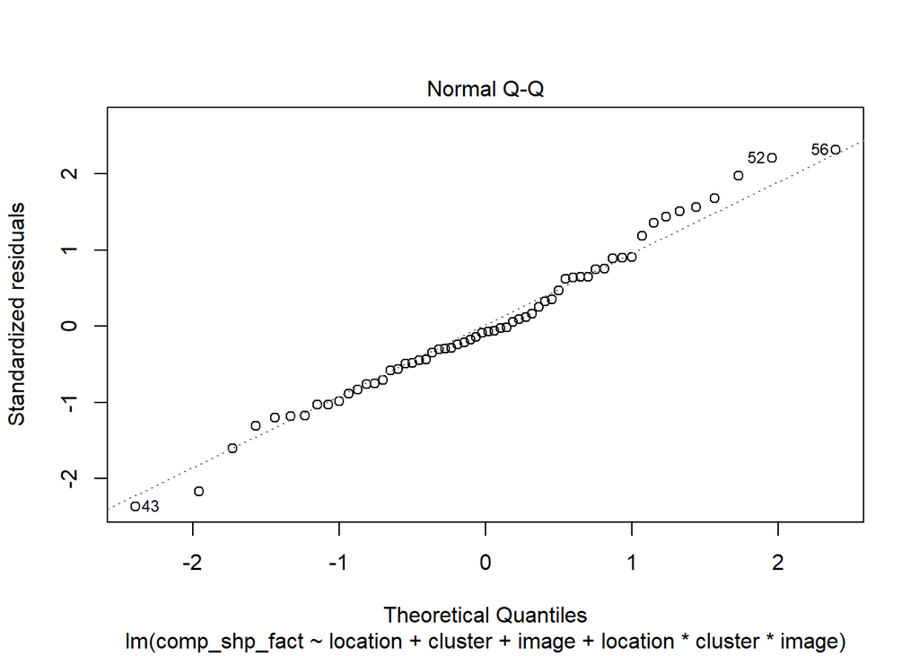

```r
plot(cmp_shp_b,which=c(1,2))
```

##Linear model and ANOVA week c only

```r
cmp_shp_c <- lm(comp_shp_fact ~ location+cluster+image+location*cluster*image, weekc)
anova(cmp_shp_c)
```

```
## Analysis of Variance Table
##
## Response: comp_shp_fact
##                        Df Sum Sq Mean Sq F value   Pr(>F)
## location                1 120.36 120.360  4.1021 0.050980 .
## cluster                 1 140.63 140.630  4.7930 0.035754 *
## image                   1  17.04  17.042  0.5808 0.451396
## location:cluster        1 301.84 301.837 10.2872 0.002975 **
## location:image          1  27.72  27.723  0.9449 0.338103
## cluster:image           1  19.13  19.130  0.6520 0.425185
## location:cluster:image  1  10.73  10.734  0.3658 0.549413
## Residuals              33 968.25  29.341
## ---
## Signif. codes:  0 '***' 0.001 '**' 0.01 '*' 0.05 '.' 0.1 ' ' 1
```

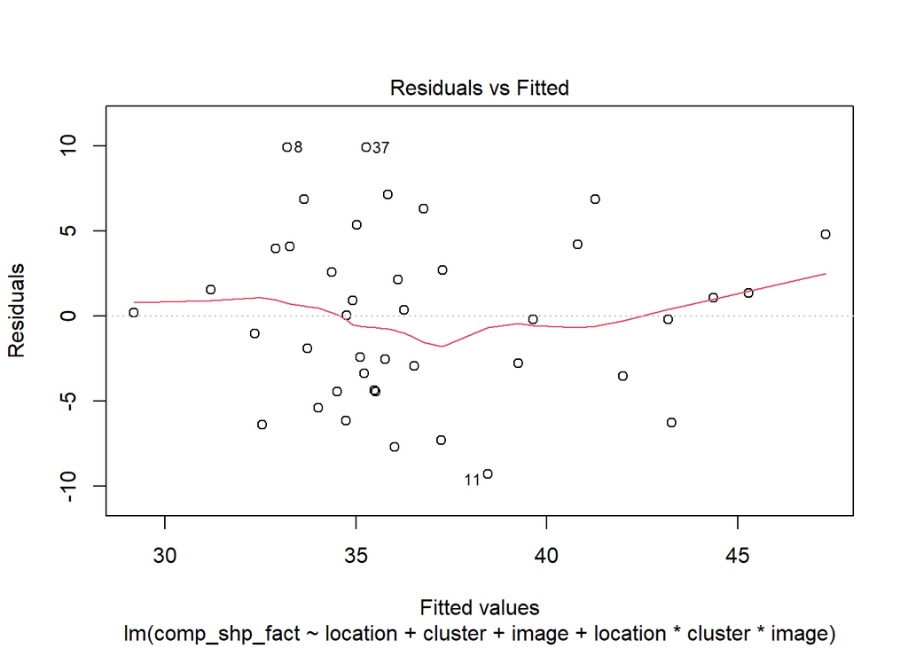

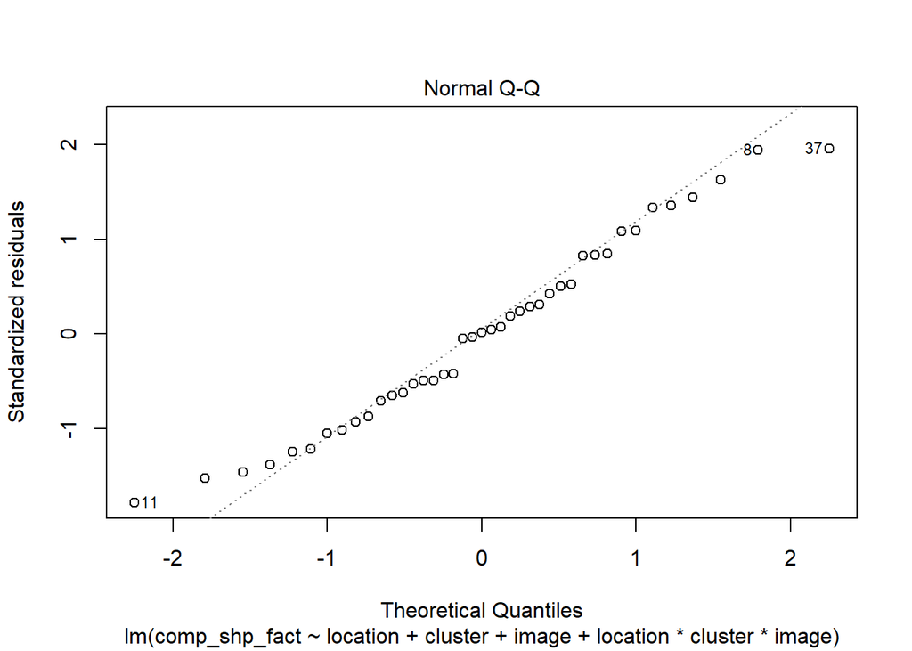

```r
plot(cmp_shp_c,which=c(1,2))
```

#Frontenac Gris ##load data

```r
#setwd("~/Desktop/Terroir_2019")
data <- read.csv("Terroir_2019_FrontenacGris.csv")
```

#aspect ratio ##Linear model and ANOVA

```r
asp_rat <- lm(aspect_ratio ~ location+cluster+image+location*cluster*image, data)
anova(asp_rat)
```

```
## Analysis of Variance Table
##
## Response: aspect_ratio
##                        Df  Sum Sq  Mean Sq F value  Pr(>F)
## location                1 0.02500 0.025000  1.6970 0.20197
## cluster                 1 0.00088 0.000884  0.0600 0.80809
## image                   1 0.00576 0.005760  0.3910 0.53621
## location:cluster        1 0.09001 0.090008  6.1098 0.01895 *
## location:image          1 0.00001 0.000010  0.0007 0.97938
## cluster:image           1 0.02673 0.026730  1.8145 0.18744
## location:cluster:image  1 0.00059 0.000587  0.0398 0.84309
## Residuals              32 0.47141 0.014732
## ---
## Signif. codes:  0 '***' 0.001 '**' 0.01 '*' 0.05 '.' 0.1 ' ' 1
```

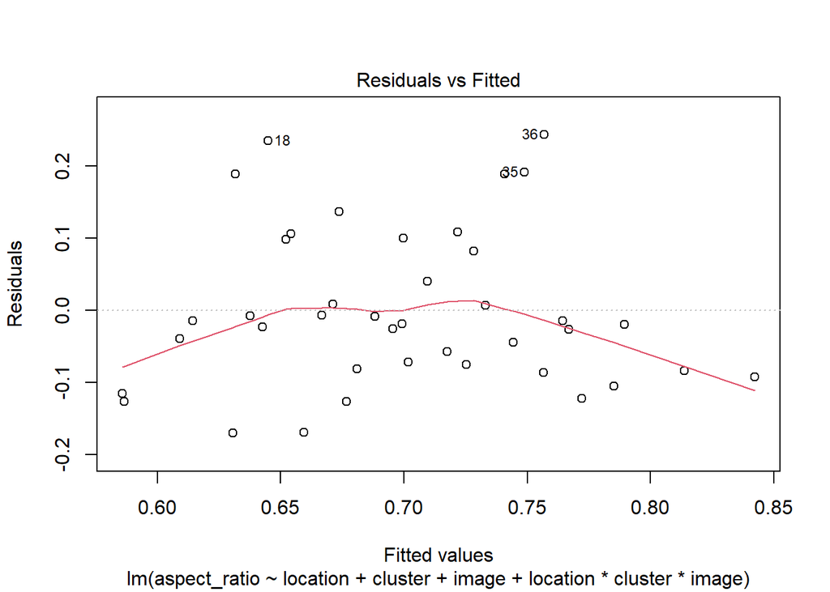

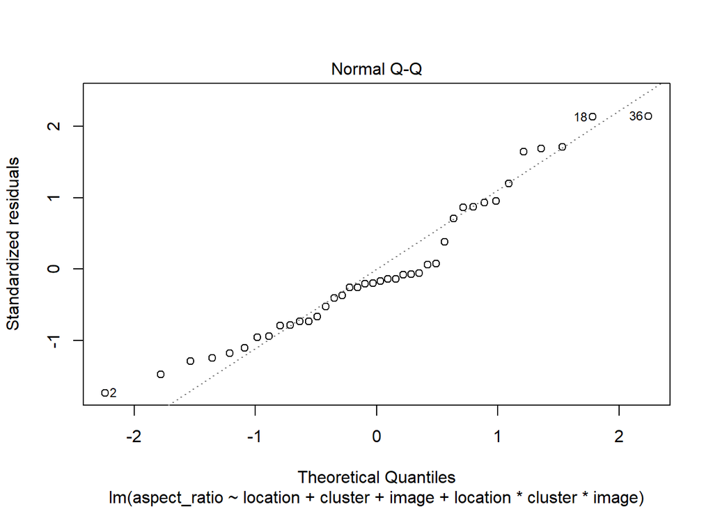

```r
plot(asp_rat,which=c(1,2))
```

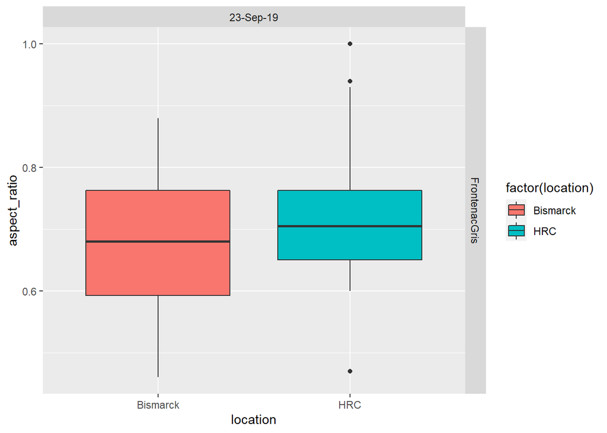

```r
ggplot(data, aes(aspect_ratio, location, fill=factor(location)))+ #use this box plot!
  geom_boxplot()+
  coord_flip()+
  facet_grid(variety~date, scales="free")
```

#cluster roundness ##linear model and ANOVA

```r
cl_rnd <- lm(cluster_roundness ~ location+cluster+image+location*cluster*image, data)
anova(cl_rnd)
```

```
## Analysis of Variance Table
##
## Response: cluster_roundness
##                        Df   Sum Sq  Mean Sq F value   Pr(>F)
## location                1 0.000810 0.000810  0.2686 0.607856
## cluster                 1 0.007953 0.007953  2.6369 0.114219
## image                   1 0.000160 0.000160  0.0531 0.819302
## location:cluster        1 0.036698 0.036698 12.1680 0.001438 **
## location:image          1 0.002560 0.002560  0.8488 0.363780
## cluster:image           1 0.000291 0.000291  0.0966 0.758016
## location:cluster:image  1 0.000728 0.000728  0.2412 0.626662
## Residuals              32 0.096510 0.003016
## ---
## Signif. codes:  0 '***' 0.001 '**' 0.01 '*' 0.05 '.' 0.1 ' ' 1
```

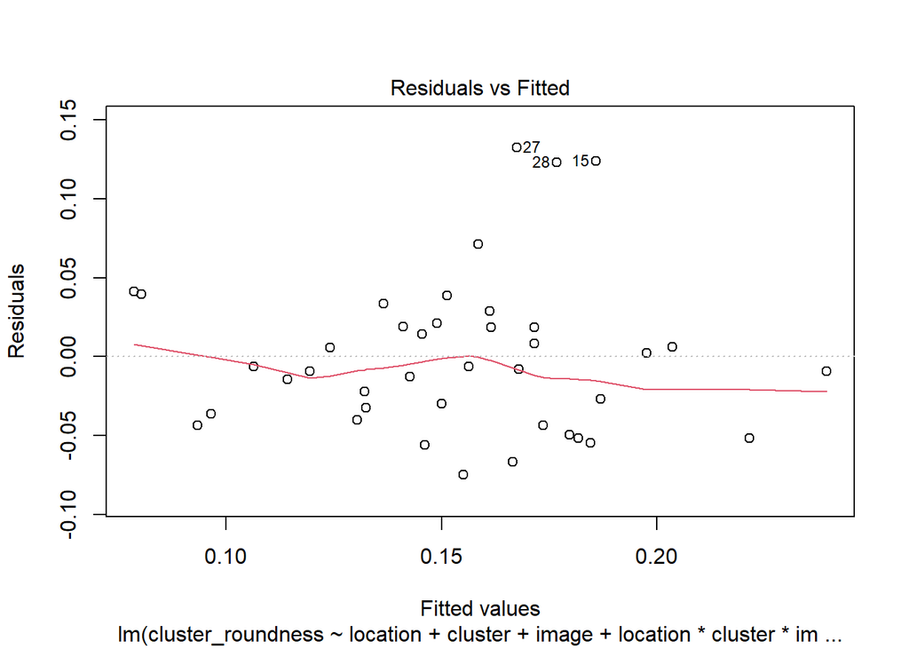

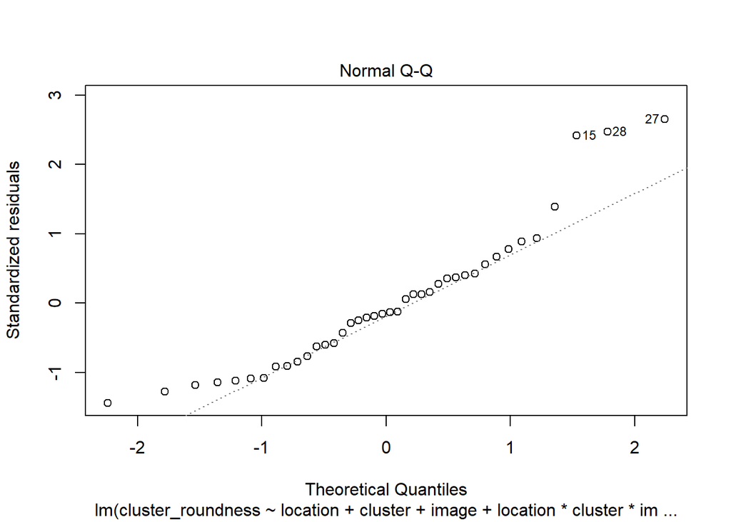

```r
plot(cl_rnd,which=c(1,2))
```

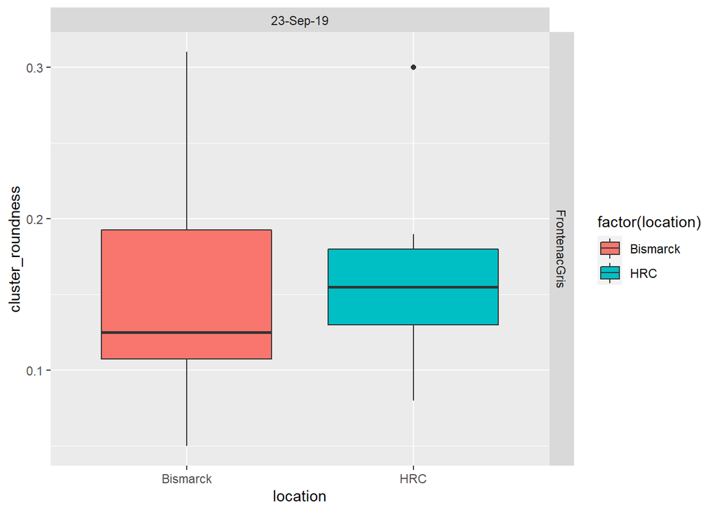

```r
ggplot(data, aes(cluster_roundness, location, fill=factor(location)))+ #use this box plot!
  geom_boxplot()+
  coord_flip()+
  facet_grid(variety~date, scales="free")
```

#compact shape factor ##Linear model and ANOVA

```r
cmp_shp <- lm(comp_shp_fact ~ location+cluster+image+location*cluster*image, data)
anova(cmp_shp)
```

```
## Analysis of Variance Table
##
## Response: comp_shp_fact
##                        Df Sum Sq Mean Sq F value  Pr(>F)
## location                1   1647  1646.6  1.1420 0.29324
## cluster                 1   7958  7958.2  5.5192 0.02515 *
## image                   1     24    24.3  0.0169 0.89751
## location:cluster        1  18658 18657.7 12.9395 0.00107 **
## location:image          1    667   667.3  0.4628 0.50121
## cluster:image           1      1     1.3  0.0009 0.97624
## location:cluster:image  1      0     0.0  0.0000 0.99723
## Residuals              32  46141  1441.9
## ---
## Signif. codes:  0 '***' 0.001 '**' 0.01 '*' 0.05 '.' 0.1 ' ' 1
```

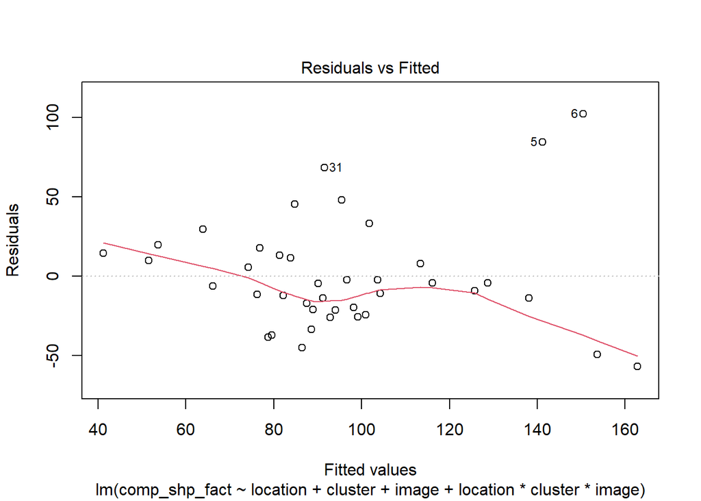

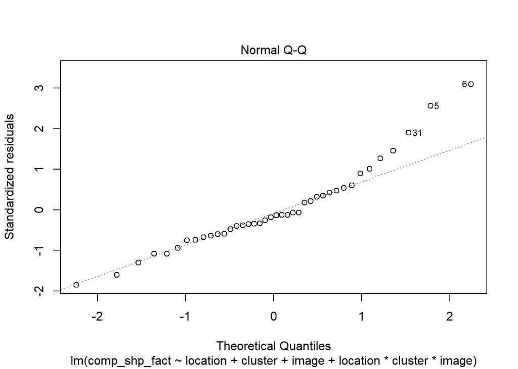

```r
plot(cmp_shp,which=c(1,2))
```

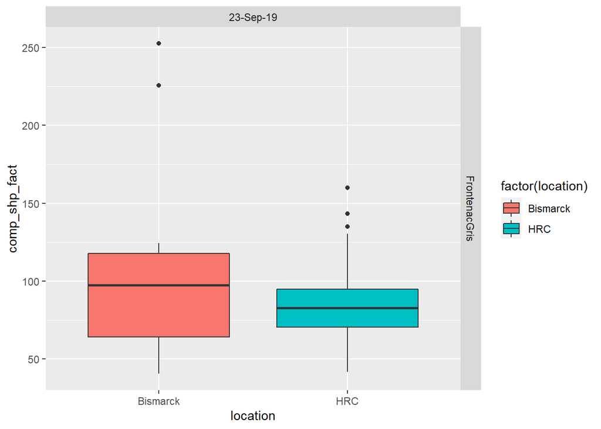

```r
ggplot(data, aes(comp_shp_fact, location, fill=factor(location)))+ #use this box plot!
  geom_boxplot()+
  coord_flip()+
  facet_grid(variety~date, scales="free")
```

#LaCrescent ##load data

```r
data <- read.csv("Terroir_2019_LaCrescent.csv")
```

##partition data

```r
weeka <- filter(data, data$sample_week =="a")
weekb <- filter(data, data$sample_week =="b")
```

#aspect ratio ##Linear model and ANOVA

```r
asp_rat <- lm(aspect_ratio ~ location+cluster+image+date+location*cluster*image*date, data)
anova(asp_rat)
```

```
## Analysis of Variance Table
##
## Response: aspect_ratio
##                              Df  Sum Sq  Mean Sq F value  Pr(>F)
## location                      1 0.14352 0.143521  5.4004 0.02208 *
## cluster                       1 0.06012 0.060122  2.2623 0.13559
## image                         1 0.14370 0.143705  5.4073 0.02199 *
## date                          1 0.01745 0.017448  0.6565 0.41964
## location:cluster              1 0.03977 0.039773  1.4966 0.22396
## location:image                1 0.05328 0.053276  2.0047 0.15981
## cluster:image                 1 0.08868 0.088677  3.3367 0.07062 .
## location:date                 1 0.04446 0.044457  1.6728 0.19875
## cluster:date                  1 0.02193 0.021930  0.8252 0.36576
## image:date                    1 0.01953 0.019530  0.7349 0.39328
## location:cluster:image        1 0.09193 0.091928  3.4591 0.06573 .
## location:cluster:date         1 0.01806 0.018058  0.6795 0.41165
## location:image:date           1 0.01415 0.014148  0.5324 0.46725
## cluster:image:date            1 0.00035 0.000352  0.0132 0.90859
## location:cluster:image:date   1 0.01015 0.010150  0.3819 0.53792
## Residuals                   104 2.76390 0.026576
## ---
## Signif. codes:  0 '***' 0.001 '**' 0.01 '*' 0.05 '.' 0.1 ' ' 1
```

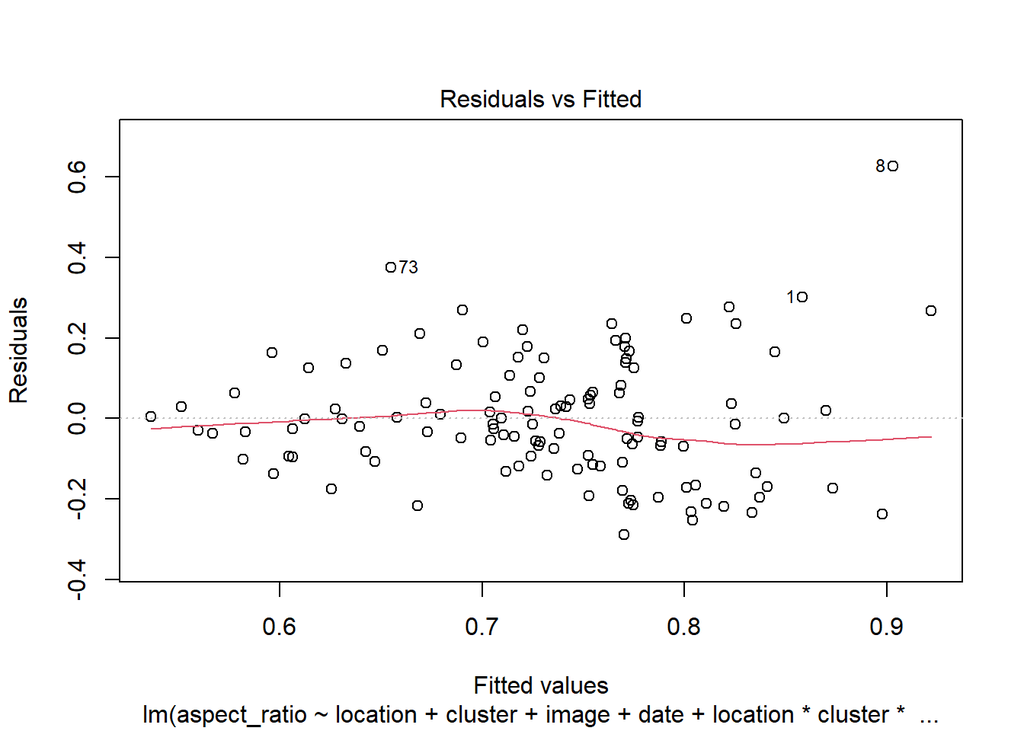

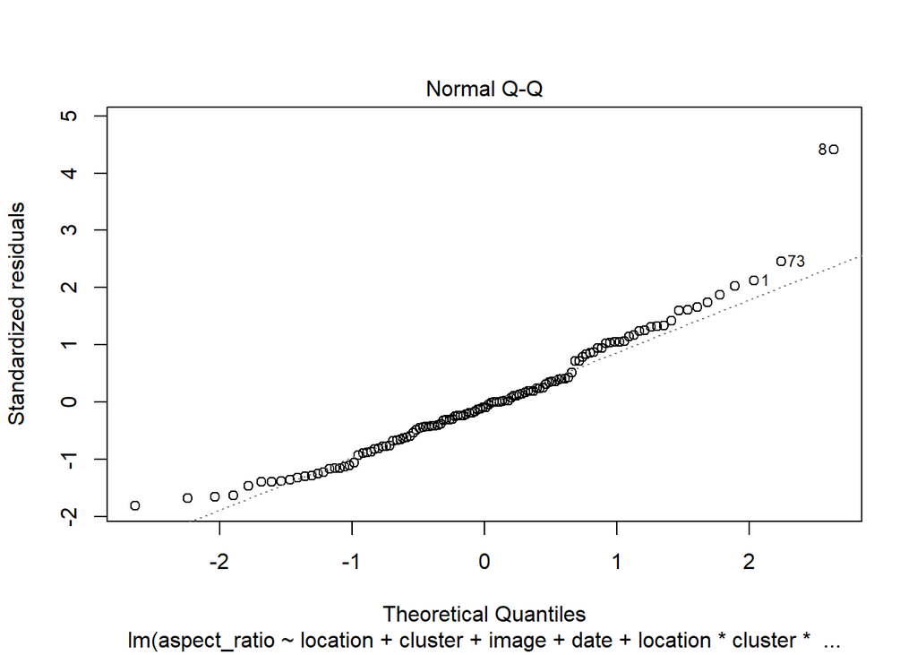

```r
plot(asp_rat,which=c(1,2))
```